# lab4

B. Moran

24 August 2016

### Generating Synthetic Time Series in R

1. Create the vector $u = [1 2 3 4 5 6 7 8 9 ]'$:

```r
u <- seq(1,9, by =1)
```

2. Generate the moving average series $v_{t}$ according to $v_{t} = \frac{1}{2}u_{t}+ \frac{1}{3}u_{t-1} + \frac{1}{}u_{t-2}$ for $t = 3, 4, \cdots ,9$:

```r
v <- filter(u, sides = 1, c(1/2, 1/3, 1/6), method = ("convolution"))
tidy(as.data.frame.ts(v))
```

```
##   column n     mean       sd   median  trimmed    mad      min      max
## 1      x 7 5.333333 2.160247 5.333333 5.333333 2.9652 2.333333 8.333333
##   range          skew  kurtosis        se
## 1     6 -2.768947e-16 -1.714286 0.8164966
```

```r
v2 <- filter(u, sides = 1, c(1/2,1/3,1/6))
v2
## Time Series:
## Start = 1
## End = 9
## Frequency = 1
## [1]       NA       NA 2.333333 3.333333 4.333333 5.333333 6.333333 7.333333
## [9] 8.333333
```

3. Generate the moving average series $w_{t}$ according to $w_{t} = \frac{1}{2}u_{t+1} + \frac{1}{3}u_{t} + \frac{1}{}u_{t-1}$ for $t = 2, 3, \cdots ,8$:

```r
w <- filter(u, sides = 2, c(1/2,1/3,1/6), method = ("convolution"))
w
## Time Series:
## Start = 1
## End = 9
## Frequency = 1
## [1]       NA 2.333333 3.333333 4.333333 5.333333 6.333333 7.333333 8.333333
## [9]       NA
w2 <- filter(u, c(1/2,1/3,1/6))
w2
## Time Series:
## Start = 1
## End = 9
## Frequency = 1
## [1]       NA 2.333333 3.333333 4.333333 5.333333 6.333333 7.333333 8.333333
## [9]       NA
```

4. What will happen if the length of filter is an even number? Run the following code and see the output:

```r
x <- filter(u, rep(1,4))
x
## Time Series:
## Start = 1
## End = 9
## Frequency = 1
## [1] NA 10 14 18 22 26 30 NA NA
```

5. Generate the autoregressive series yt according to $y_{t} = -2y_{t-1} + 3y_{t-2} + u_{t}$ for $t = 1,2,\cdots ,9$ with the initial values $y_{0} = -1$ and $y_{1} = 4$:

```r
y <- filter(u, c(-2, 3), method = ("recursive"), init = c(-1,4))
y
## Time Series:
## Start = 1
## End = 9
## Frequency = 1
## [1]     15    -31    110   -309    953  -2827   8520 -25513  76595
```

6. Generate the autoregressive series zt according to $z_{t} = -2z_{t-1} + 3z_{t-2} + u_{t}$ for $t = 1,2,\cdots ,9$ with the initial values $z_{0} = z_{1} = 0$:

```r
z <- filter(u, c(-2, 3), method = ("recursive"), init = c(0,0))
z
## Time Series:
## Start = 1
## End = 9
## Frequency = 1
## [1]    1    0    6   -8   39  -96  316 -912 2781
z <- filter(u, c(-2, 3), method = ("recursive"))
z
## Time Series:
## Start = 1
## End = 9
## Frequency = 1
## [1]    1    0    6   -8   39  -96  316 -912 2781
```

7. 1. Generate $n = 100$ observations from the autoregressive model

$$X_{t} = -0.9X_{t-2} + \mathcal{W}_{t}$$

where $\mathcal{W}_{t}$ is Gaussian White Noise with $\sigma_\mathcal{W}^{2} = 1$.

```r
w = rnorm(100,0,1)
x = filter(w, c(0,-0.9), method = "recursive")
```

2. Next, generate the moving average series

$$Y_{t} = \frac{X_{t} + X_{t-1} + X_{t-2} + X_{t-3}}{4}$$

```r
y = filter(x, sides = 1, rep(1/4,4))
```

3. Plot $X_{t}$ as a line and superimpose $Y_{t}$ as a dashed line.

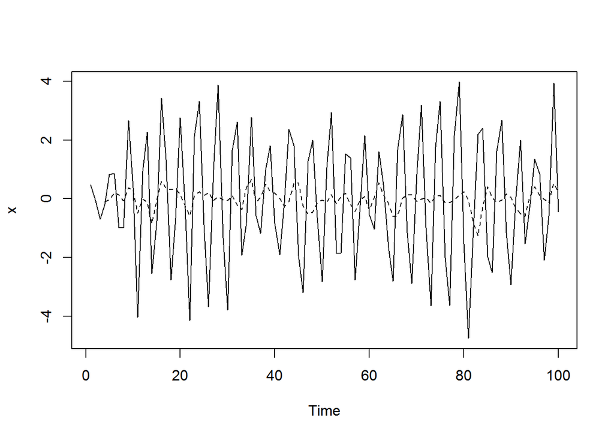

```r
plot(x, type="l")
lines(y, lty = "dashed")
```

4. Plot the ACF of $X_{t}$ and $Y_{t}$ next to each other.

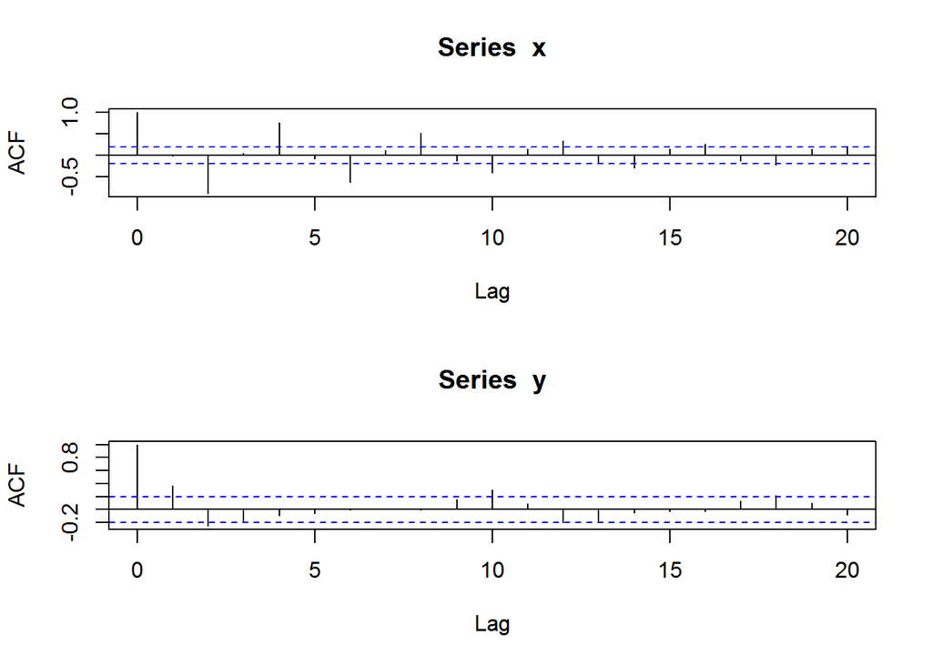

```r
par(mfrow=c(2,1))
acf(x)
acf(y, na.action = na.pass)
```

#### References

R.H. Shumway and D.S. Sto er, Time Series Analysis and Its Applications With R Examples, Springer, New York, 2010.